# Einführung in SEM

Übung 2

Dr. Henrik K. Andersen

Oktober 2022

## Mediationsmodelle

### Aufgabe 1

Schätzen Sie folgendes bivariates Modell:

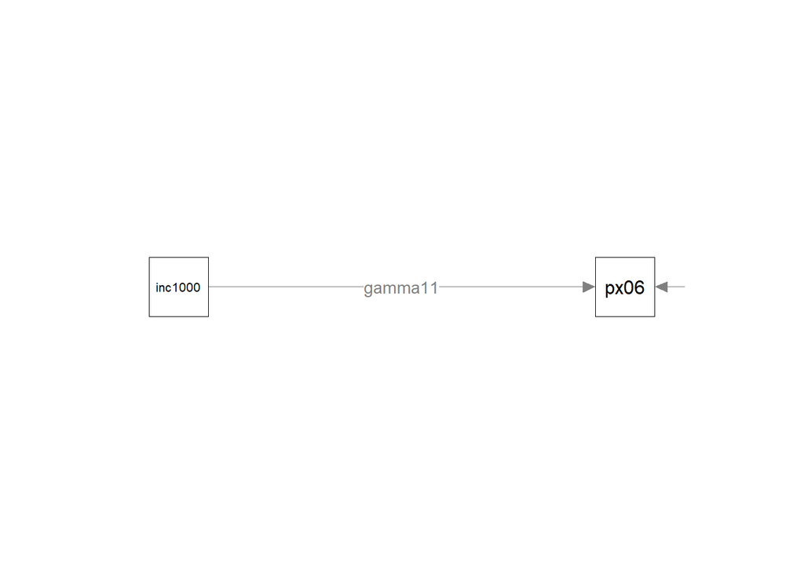

Laden Sie das `lavaan` Paket.

```r
##
```

Inspizieren Sie die verwendeten Variablen mit `head()`, `hist()`. Die Variable `inc1000` ist einfach die ursprüngliche Variable `inc` dividiert durch 1000.

```r
##
```

Schätzen Sie das Modell und fordern Sie eine Zusammenfassung des Modells an.

```r
# Bitte nennen Sie das Objekt m1 und das gefittete Modell m1.fit.
```

Interpretieren Sie die Regressionskoeffizienten. Gibt es einen totalen Effekt?

```r
# Sie können Ihre Antwort als Kommentar eingeben.
```

### Aufgabe 2

Schätzen Sie folgendes Mediationsmodell:

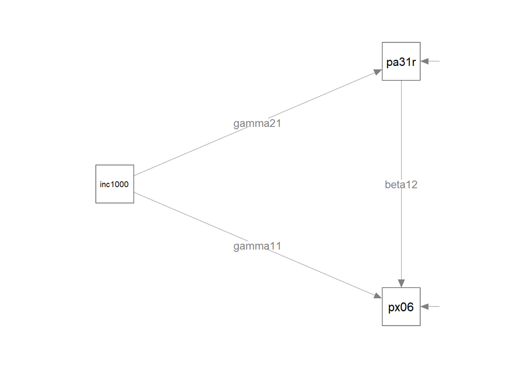

Inspizieren Sie noch die Variable `pa31r` mit `head()`.

```r
##
```

Schätzen Sie das Modell und fordern Sie eine Zusammenfassung des Modells an.

```r
# Bitte nennen Sie das Objekt m2 und das gefittete Modell m2.fit.
```

Interpretieren Sie die Regressionskoeffizienten.

```r
# Sie können Ihre Antwort als Kommentar eingeben.
```

Erweitern Sie das Mediationsmodell in dem Sie den direkten und den indirekten Effekt von `inc1000` auf `px06` definieren.

```r
# Bitte nennen Sie das Objekt m3 und das gefittete Modell m3.fit.
```

Schätzen Sie das Modell mit Mittelwertstruktur.

```r
# Bitte nennen Sie das Objekt m4 und das gefittete Modell m4.fit.
```

Laden Sie das `semPlot` Paket.

```r
##
```

Erstellen Sie ein Pfaddiagramm des letzten Modells mit `semPaths()`. Sie können die Mittelwertstruktur mit `intercepts = TRUE` hinzufügen.

```r
##
```

### Aufgabe 3

Schätzen Sie das zweite Modell (`m2`) erneut diesmal getrennt für Männer und Frauen (Variable `frau`). Dazu müssen Sie die Labels von `m2` entweder entfernen oder getrennte Labels für die Gruppen verwenden (z.B., `c(label1, label2)`).

```r
# Bitte nennen Sie das Objekt m5 und das gefittete Modell m5.fit.
```